Importing all the necessary libraries:

```python
import pandas as pd
import matplotlib.pyplot as plt
from statsmodels.tsa.stattools import adfuller
from statsmodels.graphics.tsaplots import plot_acf, plot_pacf
import statsmodels.api as sm
import forecast
import numpy as np
from statsmodels.tsa.api import ExponentialSmoothing, Holt
from statsmodels.tsa.holtwinters import ExponentialSmoothing
from forecast import histogram, qq_plot
from sklearn.metrics import mean_squared_error
from statsmodels.tsa.arima.model import ARIMA
from sklearn.model_selection import train_test_split
import seaborn as sns
from pmdarima.arima import ndiffs
from pmdarima.pipeline import Pipeline
from pmdarima.preprocessing import BoxCoxEndogTransformer
import pmdarima as pm
from sklearn.metrics import mean_absolute_error, mean_squared_error
from math import sqrt
from statsmodels.graphics.tsaplots import plot_predict
from forecast import intervalforecast
```

```python
!pip install pmdarima
```

# Executive Summary, Background, and EDA

### Executive Summary:

The aim of this report's thorough investigation is to anticipate the quarterly Consumer Price Index (CPI) for the period of March 2022 to December 2023. ARIMA, SARIMA, and Holt-Winters Exponential Smoothing are among the time series forecasting models that were created and thoroughly tested using historical data spanning from March 1997 to December 2021. Developing the model that best captures the data's trends and seasonal variations was the goal in order to ensure precise, forward-looking CPI forecasts. Among the models that were examined, the Holt-Winters model was the best option since it had the lowest Root Mean Squared Error (RMSE) and performed better at controlling the trend and seasonality components. This forecasting model offers crucial insights into anticipated inflation patterns, equipping companies and governments with significant information to make well-informed economic decisions, modify pricing strategies, and reduce inflation-related risks during the forecast period. The following sections provide detailed information on the modeling process, training steps, and analysis.

### Exploratory Data Analysis (EDA):

```python
df = pd.read_csv('CPI_train.csv', index_col='Quarter', parse_dates=True, dayfirst=True)
df.head()

print(df.isnull().sum())
df
```

```
CPI    0
dtype: int64
```

| Quarter | CPI |
| --- | --- |
| Mar-97 | 94.5 |
| Jun-97 | 93.1 |
| Sep-97 | 95.4 |
| Dec-97 | 96.3 |
| Mar-98 | 96.0 |
| ... | ... |
| Dec-20 | 125.3 |
| Mar-21 | 123.6 |
| Jun-21 | 124.5 |
| Sep-21 | 126.2 |
| Dec-21 | 125.8 |

100 rows × 1 columns

This dataset is clean, with no missing data. We have consistent CPI values for every quarter from March 1997 to December 2021.

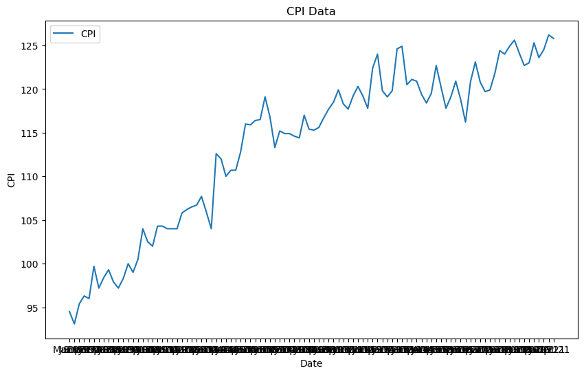

```python
# plot the CPI data
plt.figure(figsize=(10, 6))
plt.plot(df.index, df['CPI'], label='CPI')
plt.title('CPI Data')
plt.xlabel('Date')
plt.ylabel('CPI')
plt.legend()
plt.show()
```

A systematic long-term increase in prices, most likely brought on by inflationary pressures in the economy, is shown in the quarterly CPI data from 1997 to 2021. Since CPI data is less impacted by seasonal factors than other forms of data, the lack of a clear seasonal pattern suggests that price fluctuations do not follow a predictable intra-year cycle. Even while there are some medium-term variations, they don't show up as consistent cyclic patterns, indicating that erratic economic events rather than predictable cycles are what drive CPI changes. Short-term noise or abnormalities are also prevalent; they are probably random price shocks brought on by unanticipated economic disturbances. The selection of forecasting models is guided by these attributes taken together, with an emphasis on managing irregular fluctuations and tracking the trend.

```python
print(df.describe())
```

```
              CPI
count  100.000000
mean   113.704000
std      9.187496
min     93.100000
25%    105.875000
50%    116.600000
75%    120.350000
max    126.200000
```

Summary Statistics of CPI:

- Mean: 113.70
- Standard Deviation: 9.19
- Minimum CPI: 93.1 (recorded in June 1997).
- Maximum CPI: 126.2 (recorded in September 2021).
- The 50th percentile (Median): 116.6.

On average, the CPI has risen over time, hovering at 113.70. Prices have increased by around 33 units throughout the period, as indicated by the range of 93.1 to 126.2. The CPI figures exhibit moderate fluctuation, as indicated by the standard deviation of 9.19.

### Data splitting

```python
y = df['CPI']

# define an 80-20 split
train_size = round(y.shape[0] * 0.8)
train, validation = train_test_split(y, train_size=0.8, shuffle=False)
print("Training set shape:", train.shape)
print("Validation set shape:", validation.shape)
```

```
Training set shape: (80,)
Validation set shape: (20,)
```

For univariate time series modelling, it is better to work with a pandas series rather than dataframe.

```python
y
```

```
Quarter
Mar-97     94.5
Jun-97     93.1
Sep-97     95.4
Dec-97     96.3
Mar-98     96.0
          ...
Dec-20    125.3
Mar-21    123.6
Jun-21    124.5
Sep-21    126.2
Dec-21    125.8
Name: CPI, Length: 100, dtype: float64
```

# Assumptions

### Dickey-Fuller Test

```python
result = adfuller(y)
print("Dickey-Fuller Test Results:")
print(f"ADF Statistic: {result[0]}")
print(f"p-value: {result[1]}")
print(f"Critical Values:")

for key, value in result[4].items():
    print(f"   {key}: {value:.3f}")
```

```
Dickey-Fuller Test Results:
ADF Statistic: -2.13319883570975
p-value: 0.23137636262646366
Critical Values:
   1%: -3.503
   5%: -2.893
   10%: -2.584
```

Fail to reject the null hypothesis of non-stationarity since the p-value (0.231) is higher than the typical significance levels (e.g., 0.05). As a result, the series is probably not stationary and could require transformation or differencing to become stationary.

### ACF and PACF Plots

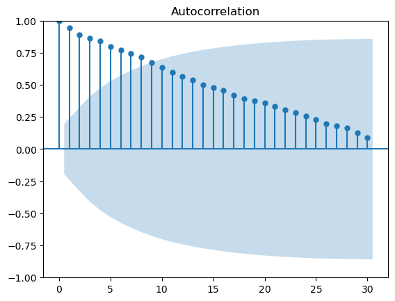

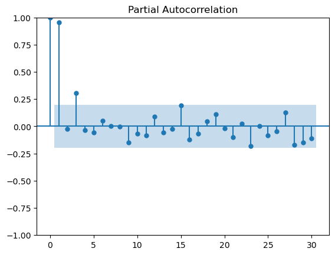

```python
plot_acf(y, lags=30, alpha=0.05)
plot_pacf(y, lags=30, alpha=0.05)

plt.show()
```

#### Discussion

- ACF: A non-stationary series is characterized by a slow decay, as shown in the ACF plot. The series most likely exhibits trend or non-stationary behavior, as seen by the autocorrelation's slow decrease with increasing lag.
- PACF: The partial autocorrelation function, or PACF, plot displays a steep decline following the first few lags. This might suggest that an AR term would be suitable if differencing is used to attain stationarity.

### Time Series Decomposition

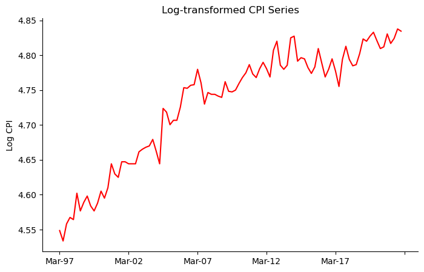

```python
# log-transformed series plot
fig, ax = plt.subplots(figsize=(8, 5))
np.log(y).plot(color='red')
ax.set_xlabel('')
ax.set_ylabel('Log CPI')
ax.set_title('Log-transformed CPI Series')
ax.set_xticks([], minor=True)
sns.despine()
plt.show()
```

The log-transformed CPI series smoothes the rising trend and stabilizes volatility, making it more suited to time series modeling. This modification lowers the impact of significant variations while highlighting underlying patterns such as trends and seasonality.

```python
window_size = 4
decomposition = sm.tsa.seasonal_decompose(y, model='additive', period=window_size)
```

```python
dir(decomposition)[-6:]
```

```
['observed', 'plot', 'resid', 'seasonal', 'trend', 'weights']
```

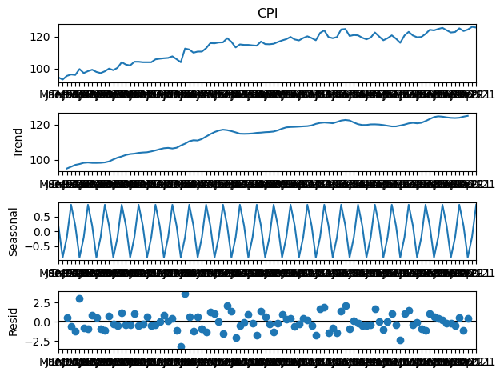

```python
decomposition.plot()
plt.show()
```

- Trend: CPI continues to rise steadily, in line with long-term inflation predictions.
- Seasonal: The seasonal component shows persistent annual changes, most likely owing to economic cycles affecting CPI. These frequent patterns might be useful in predicting.
- Residual: The residuals are typically close to zero, showing that the model captures the majority of the systematic variance. Occasional spikes may represent economic shocks that are not represented by the trend or seasonality.

# Modelling and training

### Trend corrected exponential smoothing

```python
y.index = pd.to_datetime(y.index, format='%b-%y')

# convert the index to quarterly periodindex
y.index = y.index.to_period(freq='Q')
```

```python
holt = Holt(y,initialization_method="estimated").fit()
holt.summary()
```

Holt Model Results

| Dep. Variable: | CPI | No. Observations: | 100 |
| --- | --- | --- | --- |
| Model: | Holt | SSE | 357.486 |
| Optimized: | True | AIC | 135.393 |
| Trend: | Additive | BIC | 145.813 |
| Seasonal: | None | AICC | 136.296 |
| Seasonal Periods: | None | Date: | Mon, 04 Nov 2024 |
| Box-Cox: | False | Time: | 02:15:06 |
| Box-Cox Coeff.: | None |  |  |

|  | coeff | code | optimized |
| --- | --- | --- | --- |
| smoothing_level | 0.4700264 | alpha | True |
| smoothing_trend | 2.8592e-13 | beta | True |
| initial_level | 93.951711 | l.0 | True |
| initial_trend | 0.3185969 | b.0 | True |

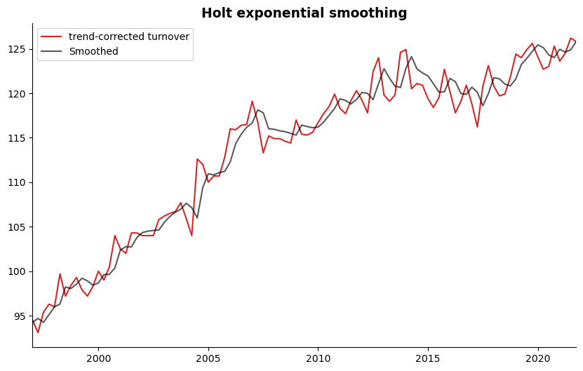

```python
smoothed = holt.fittedvalues
fig, ax= plt.subplots(figsize=(10,6))
y.plot(color='#D62728', label='trend-corrected turnover')
smoothed.plot(color='black', label='Smoothed', alpha=0.65)
plt.legend(loc='best')
ax.set_xlabel('')
ax.set_xticks([], minor=True)
ax.set_title(r'Holt exponential smoothing', fontsize=13.5, fontweight='bold')
sns.despine()
plt.show()
```

The Holt model, with an additive trend and optimized smoothing parameters, closely tracks the observed CPI values. The model's relatively low AIC and BIC indicate a good fit without overfitting. The smoothed line (black) aligns well with the observed data (red), capturing the long-term trend and some seasonal variation, though it may struggle with rapid short-term shifts. This alignment suggests the model's effectiveness for short- to medium-term forecasting while highlighting potential limitations in capturing abrupt seasonal changes.

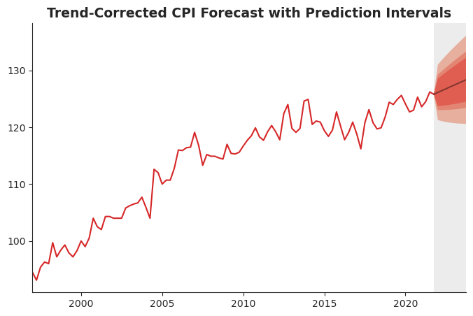

```python
h = 8  # forecasting 8 quarters ahead

# future quarterly dates for the forecast period, starting one quarter after the last date in y
test = pd.period_range(start=y.index[-1]+1, periods=h, freq='Q')
pred = pd.Series(holt.forecast(h), index=test)

intv1 = pd.DataFrame(forecast.intervalforecast(holt, h, level=.8), index=test)
intv2 = pd.DataFrame(forecast.intervalforecast(holt, h, level=.9), index=test)
intv3 = pd.DataFrame(forecast.intervalforecast(holt, h, level=.99), index=test)

fig, ax = forecast.fanchart(y['Mar-22':], pred, intv1, intv2, intv3)
ax.set_xlabel('')
ax.set_xticks([], minor=True)
plt.title('Trend-Corrected CPI Forecast with Prediction Intervals', fontsize=13.5, fontweight='bold')

sns.despine()
plt.show()
```

### Holt-winters exponential smoothing

```python
cpi_data = pd.read_csv('CPI_train.csv')
cpi_data['Quarter'] = pd.to_datetime(cpi_data['Quarter'], format='%b-%y')
cpi_data.set_index('Quarter', inplace=True)
```

```python
results = {}

# Model 1: Additive trend, additive seasonality, no damping
model_1 = ExponentialSmoothing(cpi_data['CPI'], trend='add', seasonal='add', seasonal_periods=4, initialization_method="estimated").fit()
results['Add-Add-NoDamp'] = {'AIC': model_1.aic, 'BIC': model_1.bic}

# Model 2: Additive trend, multiplicative seasonality, no damping
model_2 = ExponentialSmoothing(cpi_data['CPI'], trend='add', seasonal='mul', seasonal_periods=4, initialization_method="estimated").fit()
results['Add-Mul-NoDamp'] = {'AIC': model_2.aic, 'BIC': model_2.bic}

# Model 3: Multiplicative trend, multiplicative seasonality, no damping
model_3 = ExponentialSmoothing(cpi_data['CPI'], trend='mul', seasonal='mul', seasonal_periods=4, initialization_method="estimated").fit()
results['Mul-Mul-NoDamp'] = {'AIC': model_3.aic, 'BIC': model_3.bic}

# Model 4: Additive trend, additive seasonality, with damping
model_4 = ExponentialSmoothing(cpi_data['CPI'], trend='add', seasonal='add', seasonal_periods=4, damped_trend=True, initialization_method="estimated").fit()
results['Add-Add-Damp'] = {'AIC': model_4.aic, 'BIC': model_4.bic}

# Model 5: Additive trend, multiplicative seasonality, with damping
model_5 = ExponentialSmoothing(cpi_data['CPI'], trend='add', seasonal='mul', seasonal_periods=4, damped_trend=True, initialization_method="estimated").fit()
results['Add-Mul-Damp'] = {'AIC': model_5.aic, 'BIC': model_5.bic}

# Model 6: Multiplicative trend, multiplicative seasonality, with damping
model_6 = ExponentialSmoothing(cpi_data['CPI'], trend='mul', seasonal='mul', seasonal_periods=4, damped_trend=True, initialization_method="estimated").fit()
results['Mul-Mul-Damp'] = {'AIC': model_6.aic, 'BIC': model_6.bic}

# Model 7: Additive model with log transformation
model_7 = ExponentialSmoothing(np.log(cpi_data['CPI']), trend='add', seasonal='add', seasonal_periods=4, initialization_method="estimated").fit()
results['Add-Add-Log'] = {'AIC': model_7.aic, 'BIC': model_7.bic}

# results for each model
for model, metrics in results.items():
    print(f"{model}: AIC = {metrics['AIC']}, BIC = {metrics['BIC']}")
```

```
Add-Add-NoDamp: AIC = 122.8844962162036, BIC = 143.72585770410834
Add-Mul-NoDamp: AIC = 121.85167861448195, BIC = 142.6930401023867
Mul-Mul-NoDamp: AIC = 122.83679013344542, BIC = 143.67815162135014
Add-Add-Damp: AIC = 122.4720643767169, BIC = 145.91859605060972
Add-Mul-Damp: AIC = 121.47208380663471, BIC = 144.91861548052754
Mul-Mul-Damp: AIC = 121.69055459755026, BIC = 145.13708627144308
Add-Add-Log: AIC = -823.0459957023936, BIC = -802.2046342144889
```

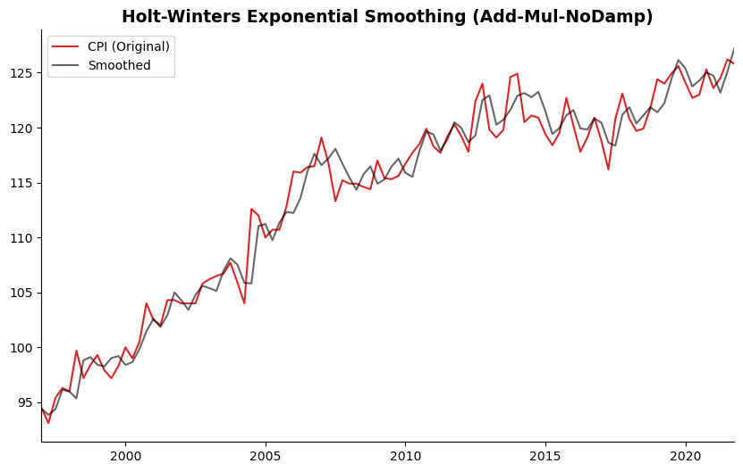

```python
# Model 2: Fit the Additive trend, multiplicative seasonality, no damping model
model_2 = ExponentialSmoothing(y, trend='add', seasonal='mul', seasonal_periods=4,
                               initialization_method="estimated").fit()

results = {}
results['Add-Mul-NoDamp'] = {'AIC': model_2.aic, 'BIC': model_2.bic}
smoothed = pd.Series(model_2.fittedvalues, index=y.index)

# plotting the original and smoothed series
fig, ax = plt.subplots(figsize=(10, 6))
y.plot(color='#D62728', label='CPI (Original)', ax=ax)
smoothed.plot(color='black', label='Smoothed', alpha=0.6, ax=ax)
plt.legend(loc='best')
ax.set_xlabel('')
ax.set_xticks([], minor=True)
ax.set_title(r'Holt-Winters Exponential Smoothing (Add-Mul-NoDamp)', fontsize=13.5, fontweight='bold')

sns.despine()
plt.show()
```

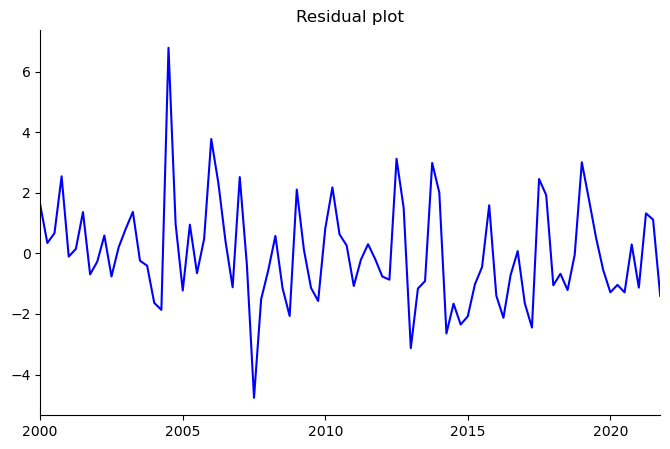

```python
resid = (y-model_2.fittedvalues)[12:]

fig, ax= plt.subplots(figsize=(8,5))
resid.plot(color='blue')
ax.set_xlabel('')
ax.set_xticks([], minor=True)
ax.set_title('Residual plot')
sns.despine()
plt.show()
```

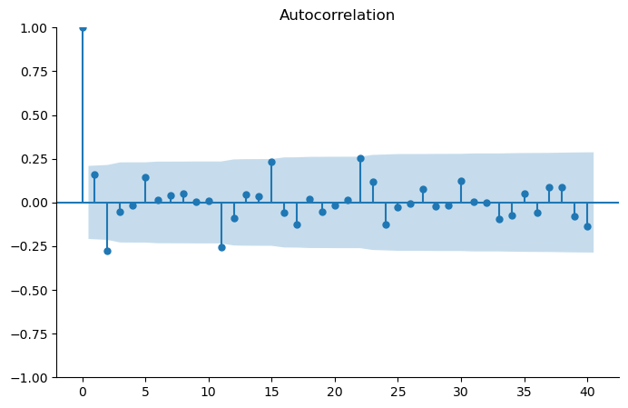

```python
fig, ax = plt.subplots(figsize=(8,5))
sm.graphics.tsa.plot_acf(resid, lags=40, ax=ax)
sns.despine()
plt.show()
```

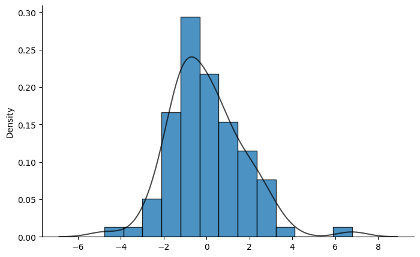

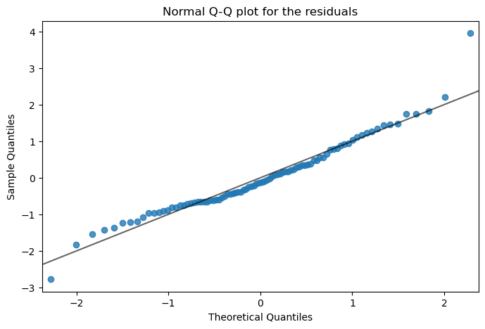

```python
histogram(resid)
plt.show()

qq_plot(resid)
plt.show()
```

```python
print('Residual skewness: {:.3f}'.format(resid.skew()))
print('Residual kurtosis: {:.3f}'.format(resid.kurt()))
```

```
Residual skewness: 0.701
Residual kurtosis: 2.023
```

#### Discussion

```python
# real time forecasting
horizon = 8  # 8 steps ahead

ts = np.log(y)  # log-transform series for log-additive model
validation = y['2009Q2':].index

# Initialize dictionaries to store predictions for each horizon
pred1, pred2, pred3, pred4, actual = {}, {}, {}, {}, {}

start = y.index.get_loc('2009Q2')

for i in range(start, len(y) - horizon + 1):
    if i + horizon > len(y):
        break

    actual[y.index[i]] = y.iloc[i:i + horizon].values

    # Seasonal random walk forecast
    pred1[y.index[i]] = y.iloc[i - 12:i - 12 + horizon].values

    # Additive Holt-Winters forecast
    model = ExponentialSmoothing(y.iloc[:i], seasonal_periods=4, trend="add",
                                 seasonal="add", initialization_method="estimated").fit()
    pred2[y.index[i]] = model.forecast(horizon)

    # Multiplicative Holt-Winters forecast
    model = ExponentialSmoothing(y.iloc[:i], seasonal_periods=4, trend="add",
                                 seasonal="mul", initialization_method="estimated").fit()
    pred3[y.index[i]] = model.forecast(horizon)

    # Log-additive Holt-Winters forecast with adjustment for retransformation
    model = ExponentialSmoothing(ts.iloc[:i], seasonal_periods=4, trend="add",
                                 seasonal="add", initialization_method="estimated").fit()
    resid = (ts.iloc[:i] - model.fittedvalues)[12:]  # residuals
    y_pred_values = np.exp(model.forecast(horizon)) * np.mean(np.exp(resid))
    pred4[y.index[i]] = y_pred_values

results = pd.DataFrame({
    'Seasonal RW': pd.Series(pred1),
    'Additive': pd.Series(pred2),
    'Multiplicative': pd.Series(pred3),
    'Log additive': pd.Series(pred4),
    'Actual': pd.Series(actual)
})
```

```python
table = pd.DataFrame(0.0, index=results.columns[:-1], columns=['RMSE'])

for i in range(len(results.columns) - 1):
    model_name = results.columns[i]
    y_pred = np.concatenate(results[model_name].values).ravel()
    y_actual = np.concatenate(results['Actual'].values).ravel()
    table.loc[model_name, 'RMSE'] = np.sqrt(mean_squared_error(y_pred, y_actual))

table = table.round(2)
table
```

|  | RMSE |
| --- | --- |
| Seasonal RW | 3.82 |
| Additive | 2.59 |
| Multiplicative | 2.58 |
| Log additive | 2.75 |

#### Discussion

Real-Time Forecasting Models:

Best Model Performance:

- Out of the four models, the Multiplicative Holt-Winters model was somewhat more accurate than the other models, with the lowest RMSE (2.58). According to this outcome, it most accurately depicts the pattern and seasonality in the CPI data.

### Forecasting on the multiplicative model

Based on the model validation, the multiplicative model preformed best(wihtout damped)

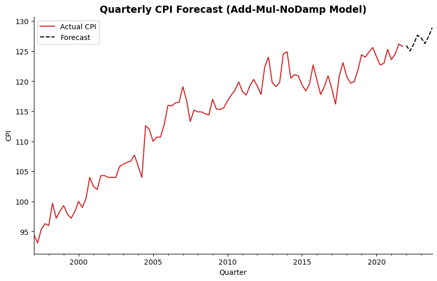

```python
best_model = ExponentialSmoothing(y, trend='add', seasonal='mul', seasonal_periods=4, initialization_method="estimated").fit()

h = 8

last_period = y.index[-1]
test_periods = pd.period_range(start=last_period + 1, periods=h, freq='Q')

pred = pd.Series(best_model.forecast(h), index=test_periods)

# plot actual values and forecast
fig, ax = plt.subplots(figsize=(10, 6))
y.plot(color='#D62728', label='Actual CPI', ax=ax)
pred.plot(color='black', linestyle='--', label='Forecast', ax=ax)
ax.set_xlabel('Quarter')
ax.set_ylabel('CPI')
plt.legend(loc='best')
plt.title('Quarterly CPI Forecast (Add-Mul-NoDamp Model)', fontsize=13.5, fontweight='bold')
sns.despine()
plt.show()
```

### Model Selection for AR/MA/ARIMA Models

### Log transform

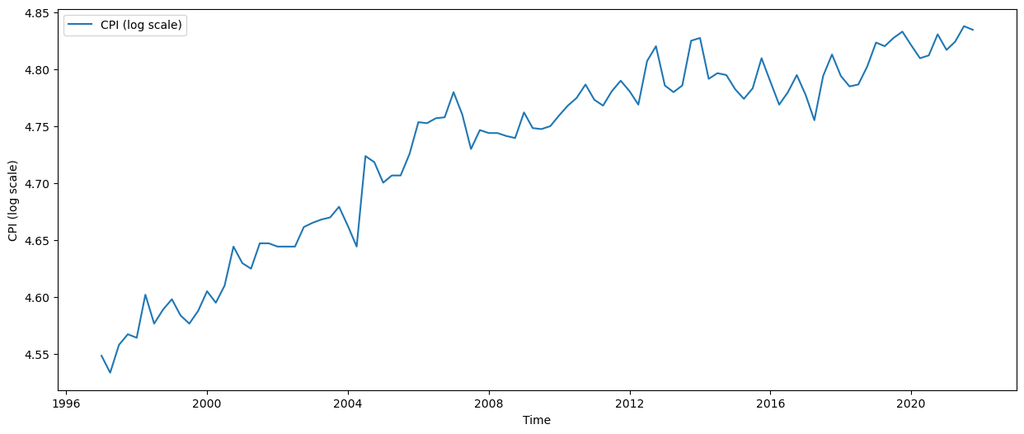

```python
y_log = np.log(y)  # log transformation

# convert periodindex to datetimeindex
y_log.index = y_log.index.to_timestamp()

# plot the log-transformed data
plt.figure(figsize=(15, 6))
plt.plot(y_log.index, y_log, label="CPI (log scale)")
plt.xlabel('Time')
plt.ylabel('CPI (log scale)')
plt.legend()
plt.show()
```

### $1^{st}$ differencing

Clearly the log transformed time series is not stationary as it has an increasing trend. Although ARIMA($p,d,q$) does not require stationary data as input, we still need to know the best integrated value $d$. Therefore, we will first try the $1^{st}$-order difference.

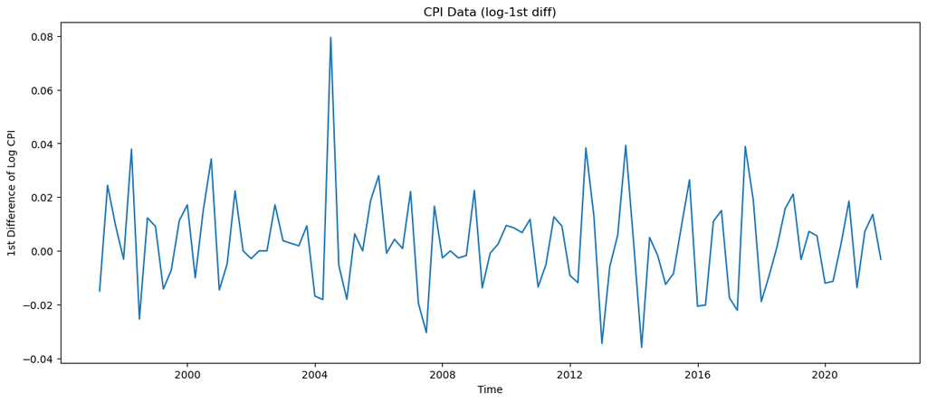

```python
# 1st order difference of the log-transformed series
y_log_diff = y_log - y_log.shift()
y_log_diff.dropna(inplace=True)

plt.figure(figsize=(15, 6))
plt.plot(y_log_diff)
plt.title("CPI Data (log-1st diff)")
plt.xlabel('Time')
plt.ylabel('1st Difference of Log CPI')
plt.show()
```

We can see the $1^{st}$ difference plot remains the same mean value and the variance does not change significantly. In this case, we can consider this data as stationary data. Then we could set the $d=1$ for the ARIMA($p,d,q$) process.

To ensure that the transformed series is stationary, we may carefully check its sample ACF. We will do it in the following step.

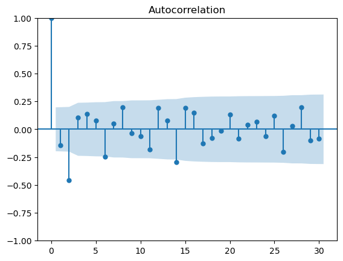

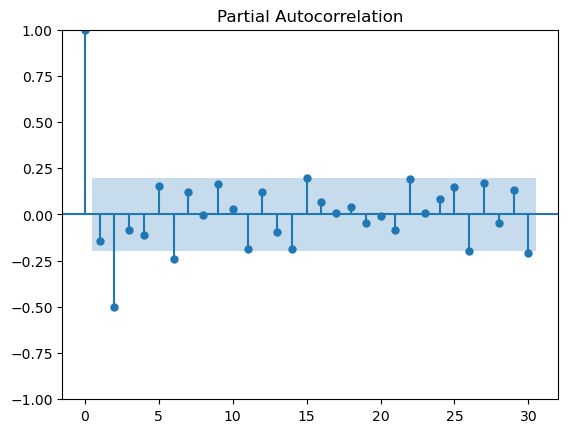

```python
plot_acf(y_log_diff, lags=30, alpha = 0.05)
plt.show()

plot_pacf(y_log_diff, lags=30, alpha = 0.05)
plt.show()
```

### Fitting ARIMA (2, 1, 1)

```python
ts_log = np.log(y)  # log transformation

model_1 = ARIMA(ts_log, order=(2, 1, 1))
model_1_fit = model_1.fit()
print(model_1_fit.summary())
```

```
                               SARIMAX Results
==============================================================================
Dep. Variable:                    CPI   No. Observations:                  100
Model:                 ARIMA(2, 1, 1)   Log Likelihood                 269.067
Date:                Mon, 04 Nov 2024   AIC                           -530.134
Time:                        02:17:52   BIC                           -519.753
Sample:                    03-31-1997   HQIC                          -525.934
                         - 12-31-2021
Covariance Type:                  opg
==============================================================================
                 coef    std err          z      P>|z|      [0.025      0.975]
------------------------------------------------------------------------------
ar.L1         -0.1859      0.258     -0.720      0.471      -0.692       0.320
ar.L2         -0.4406      0.106     -4.175      0.000      -0.647      -0.234
ma.L1          0.0421      0.261      0.161      0.872      -0.469       0.553
sigma2         0.0003    2.9e-05      8.767      0.000       0.000       0.000
===================================================================================
Ljung-Box (L1) (Q):                   0.91   Jarque-Bera (JB):                31.28
Prob(Q):                              0.34   Prob(JB):                         0.00
Heteroskedasticity (H):               0.57   Skew:                             0.93
Prob(H) (two-sided):                  0.11   Kurtosis:                         5.03
===================================================================================

Warnings:
[1] Covariance matrix calculated using the outer product of gradients (complex-step).
```

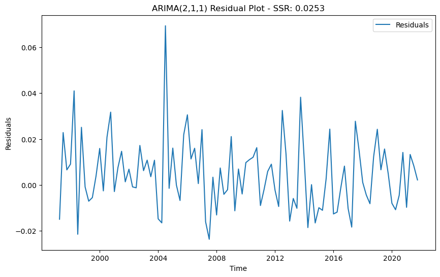

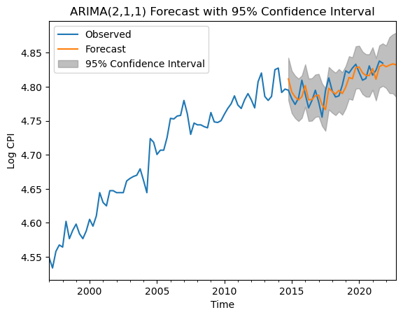

```
RMSE on original scale: 1.5684
```

```python
model_1 = ARIMA(y_log, order=(2, 1, 1))
model_1_fit = model_1.fit()

# residuals and SSR calculation
residuals = pd.DataFrame(model_1_fit.resid[1:])
residuals.index = y_log.index[1:]
plt.figure(figsize=(10, 6))
plt.plot(residuals, label="Residuals")
plt.title('ARIMA(2,1,1) Residual Plot - SSR: %.4f' % sum((model_1_fit.resid.values[1:])**2))
plt.xlabel('Time')
plt.ylabel('Residuals')
plt.legend()
plt.show()

# forecast plot
fig, ax = plt.subplots()
ax = y_log.plot(ax=ax)
plot_predict(model_1_fit, start='2015Q1', end='2022Q4', ax=ax)
plt.title('ARIMA(2,1,1) Forecast with 95% Confidence Interval')
plt.xlabel('Time')
plt.ylabel('Log CPI')
plt.legend(["Observed", "Forecast", "95% Confidence Interval"])
plt.show()

# validation set
validation = y['2017Q1':]

start = len(train)
end = start + len(validation) - 1
pred_log = model_1_fit.predict(start=start, end=end, typ="levels")

# back transform the predictions from log scale to original scale
pred_exp = np.exp(pred_log)
validation_values = validation.values.astype(float)
pred_exp_values = pred_exp.values.astype(float)

# RMSE
rmse_original_scale_arima = sqrt(mean_squared_error(validation_values, pred_exp_values))
print(f'RMSE on original scale: {rmse_original_scale_arima:.4f}')
```

### Fitting ARIMA (1, 1, 1)

```python
model_2 = ARIMA(ts_log, order=(1, 1, 1))
model_2_fit = model_2.fit()

print(model_2_fit.summary())
```

```
                               SARIMAX Results
==============================================================================
Dep. Variable:                    CPI   No. Observations:                  100
Model:                 ARIMA(1, 1, 1)   Log Likelihood                 261.617
Date:                Mon, 04 Nov 2024   AIC                           -517.234
Time:                        02:17:56   BIC                           -509.449
Sample:                    03-31-1997   HQIC                          -514.084
                         - 12-31-2021
Covariance Type:                  opg
==============================================================================
                 coef    std err          z      P>|z|      [0.025      0.975]
------------------------------------------------------------------------------
ar.L1          0.2951      0.340      0.868      0.385      -0.371       0.961
ma.L1         -0.5648      0.302     -1.869      0.062      -1.157       0.027
sigma2         0.0003   3.21e-05      9.219      0.000       0.000       0.000
===================================================================================
Ljung-Box (L1) (Q):                   0.01   Jarque-Bera (JB):                23.34
Prob(Q):                              0.91   Prob(JB):                         0.00
Heteroskedasticity (H):               0.72   Skew:                             0.71
Prob(H) (two-sided):                  0.34   Kurtosis:                         4.90
===================================================================================

Warnings:
[1] Covariance matrix calculated using the outer product of gradients (complex-step).
```

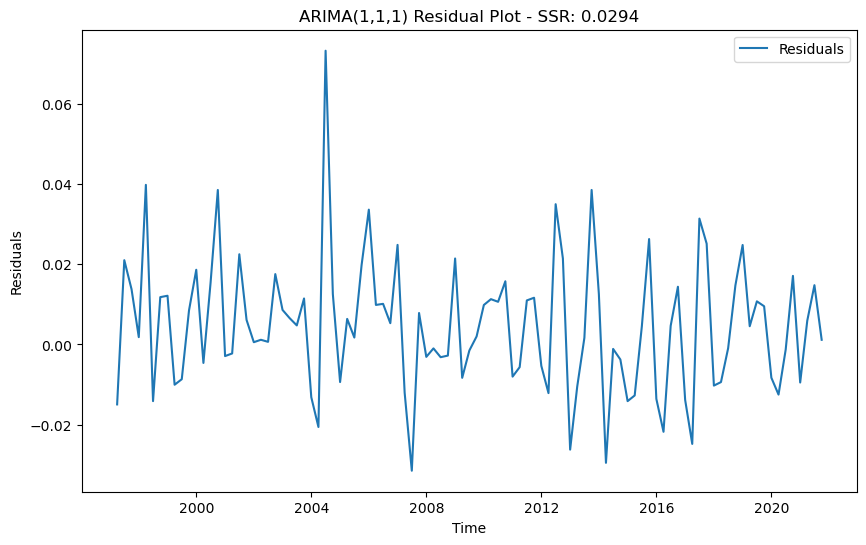

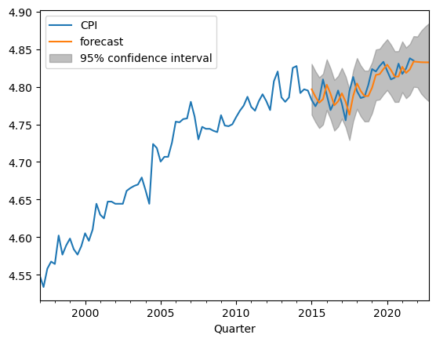

```
RMSE on original scale: 1.8248
```

```python
residuals = pd.DataFrame(model_2_fit.resid[1:])
residuals.index = residuals.index.to_timestamp()

# residuals and SSR
plt.figure(figsize=(10, 6))
plt.plot(residuals, label="Residuals")
plt.title('ARIMA(1,1,1) Residual Plot - SSR: %.4f' % sum((model_2_fit.resid.values[1:])**2))
plt.xlabel('Time')
plt.ylabel('Residuals')
plt.legend()
plt.show()

fig, ax = plt.subplots()
ax = y_log.plot(ax=ax)
plot_predict(model_2_fit, '2015Q1', '2022Q4', ax=ax)
plt.show()

validation = y['2017Q1':]

start = len(train)
end = start + len(validation) - 1
pred_log = model_2_fit.predict(start=start, end=end, typ="levels")

# back transform the predictions from log scale to original scale
pred_exp = np.exp(pred_log)
validation_values = validation.values.astype(float)
pred_exp_values = pred_exp.values.astype(float)

# RMSE
rmse_original_scale_arima = sqrt(mean_squared_error(validation_values, pred_exp_values))
print(f'RMSE on original scale: {rmse_original_scale_arima:.4f}')
```

#### Discussion

ARIMA(2,1,1):

- Residual Plot & SSR: A good fit with little error is shown by the residuals, which are comparatively tiny and dispersed about zero, and an SSR of 0.0253.
- Forecast Accuracy (RMSE): A respectable forecast accuracy for the series is indicated by the Root Mean Square Error (RMSE) of 1.5684 on the original scale.

ARIMA(1,1,1):

- Residual Plot & SSR: In comparison to the ARIMA(2,1,1) model, the residuals exhibit modest deviations and the SSR is marginally higher at 0.0294.
- Forecast Accuracy (RMSE): The ARIMA(2,1,1) model may be a better fit for this dataset, since the RMSE on the original scale is 1.8248, greater than the ARIMA(2,1,1) model.

### Using AIC and BIC to select orders (p,q)

```python
order_selection = sm.tsa.arma_order_select_ic(y_log_diff, max_ar=4, max_ma=4, ic=['aic', 'bic'])

print("\nFull AIC and BIC Tables:")
print(order_selection)
print("AIC Order Selection:")
print(order_selection.aic_min_order)
print("BIC Order Selection:")
print(order_selection.bic_min_order)
```

```
Full AIC and BIC Tables:
{'aic':             0           1           2           3           4
0 -514.229729 -522.793653 -537.214711 -541.230947 -539.767734
1 -514.238979 -525.378148 -539.254761 -538.790254 -537.712301
2 -539.196563 -537.895249 -536.641272 -537.257175 -535.177061
3 -537.722264 -535.907454 -537.223755 -535.884162 -535.081219
4 -536.761619 -535.699971 -533.677665 -533.423066 -530.053653, 'bic':             0           1           2           3           4
0 -509.039490 -515.008294 -526.834231 -528.255347 -524.197015
1 -506.453619 -514.997669 -526.279162 -523.219534 -519.546463
2 -528.816084 -524.919650 -521.070553 -519.091336 -514.416102
3 -524.746665 -520.336734 -519.057916 -515.123204 -511.725140
4 -521.190900 -517.534132 -512.916706 -510.066987 -504.102454, 'aic_min_order': (0, 3), 'bic_min_order': (2, 0)}
AIC Order Selection:
(0, 3)
BIC Order Selection:
(2, 0)
```

### AIC Order Selection ARIMA(0,1,3)

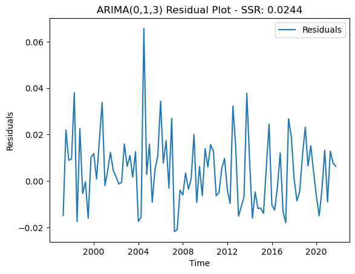

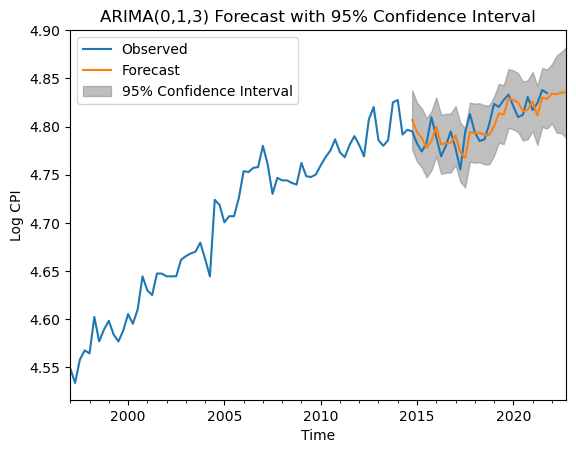

```
RMSE on original scale for ARIMA(0,1,3): 1.5903
```

```python
p, d, q = 0, 1, 3

model_AIC = ARIMA(y_log, order=(p, d, q))
results_AIC_ARIMA = model_AIC.fit()
residuals_AIC = pd.DataFrame(results_AIC_ARIMA.resid[1:])
residuals_AIC.index = y_log.index[1:]

plt.figure()
plt.plot(residuals_AIC, label="Residuals")
plt.title('ARIMA(0,1,3) Residual Plot - SSR: %.4f' % sum((results_AIC_ARIMA.resid.values[1:])**2))
plt.xlabel('Time')
plt.ylabel('Residuals')
plt.legend()
plt.show()

fig, ax = plt.subplots()
ax = y_log.plot(ax=ax)
plot_predict(results_AIC_ARIMA, start='2015Q1', end='2022Q4', ax=ax)
plt.title('ARIMA(0,1,3) Forecast with 95% Confidence Interval')
plt.xlabel('Time')
plt.ylabel('Log CPI')
plt.legend(["Observed", "Forecast", "95% Confidence Interval"])
plt.show()

validation = y['2017Q1':]

start = len(train)
end = start + len(validation) - 1
pred_log = results_AIC_ARIMA.predict(start=start, end=end, typ="levels")

# back transform the predictions from log scale to original scale
pred_exp = np.exp(pred_log)
validation_values = validation.values.astype(float)
pred_exp_values = pred_exp.values.astype(float)

# RMSE
rmse_original_scale_arima = sqrt(mean_squared_error(validation_values, pred_exp_values))
print(f'RMSE on original scale for ARIMA(0,1,3): {rmse_original_scale_arima:.4f}')
```

### BIC Order Selection ARIMA(2,1,0)

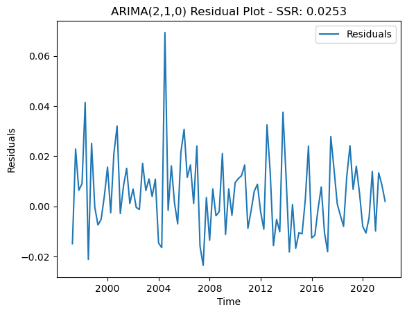

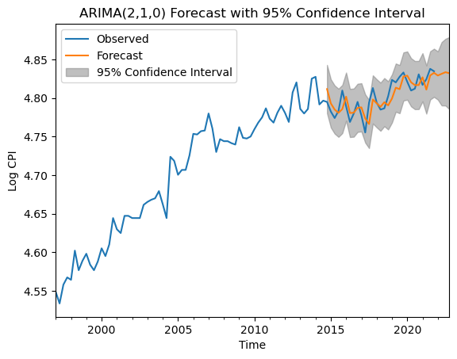

```
RMSE on original scale: 1.5656
```

```python
p, d, q = 2, 1, 0

model_BIC = ARIMA(y_log, order=(p, d, q))
results_BIC_ARIMA = model_BIC.fit()
residuals_BIC = pd.DataFrame(results_BIC_ARIMA.resid[1:])
residuals_BIC.index = y_log.index[1:]

plt.figure()
plt.plot(residuals_BIC, label="Residuals")
plt.title('ARIMA(2,1,0) Residual Plot - SSR: %.4f' % sum((results_BIC_ARIMA.resid.values[1:])**2))
plt.xlabel('Time')
plt.ylabel('Residuals')
plt.legend()
plt.show()

fig, ax = plt.subplots()
ax = y_log.plot(ax=ax)
plot_predict(results_BIC_ARIMA, start='2015Q1', end='2022Q4', ax=ax)
plt.title('ARIMA(2,1,0) Forecast with 95% Confidence Interval')
plt.xlabel('Time')
plt.ylabel('Log CPI')
plt.legend(["Observed", "Forecast", "95% Confidence Interval"])
plt.show()

# predictions on the validation set
start = len(train)
end = start + len(validation) - 1
pred_log = results_BIC_ARIMA.predict(start=start, end=end, typ="levels")

# convert predictions back from log scale
pred_exp = np.exp(pred_log)

# convert index to quarterly periods
pred_exp.index = pd.period_range(start='2017Q1', periods=len(pred_exp), freq='Q')

# RMSE
rmse_original_scale_bic = sqrt(mean_squared_error(validation, pred_exp))
print(f'RMSE on original scale: {rmse_original_scale_bic:.4f}')
```

#### Discussion

ARIMA(0,1,3):

- This model appears to fit the data reasonably, as seen by its reduced RMSE of 1.5903 on the original scale.
- Although the confidence interval marginally widens in the anticipated region, indicating more uncertainty, the prediction plot nearly matches the observed values.

ARIMA(2,1,0):

- This model offers a somewhat better fit than ARIMA(0,1,3), with an RMSE of 1.5656 on the original scale.
- With reduced autocorrelation and a more steady appearance near zero, the residuals lend credence to the model's ability to accurately depict the data pattern.

## Forecasting with SARIMA

### Time series analysis

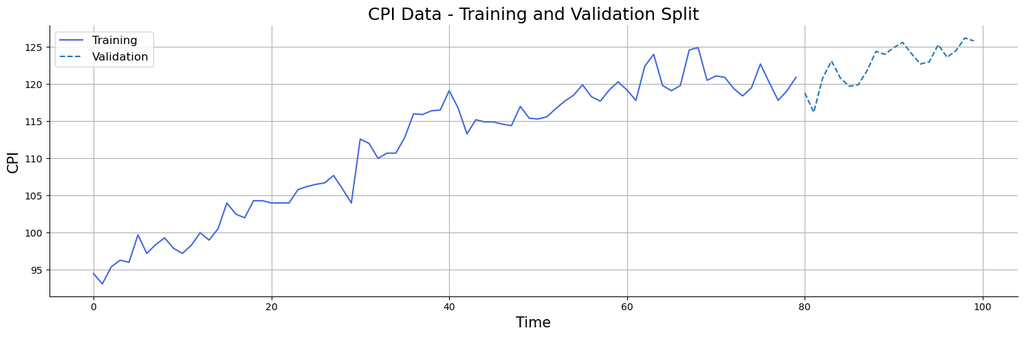

```python
x_train = np.arange(train.shape[0])
x_val = np.arange(train.shape[0], train.shape[0] + validation.shape[0])

# plotting the training and validation data
plt.figure(figsize=(15, 5))
plt.plot(x_train, train, color='royalblue', label='Training')
plt.plot(x_val, validation, linestyle='--', color='tab:blue', label='Validation')
plt.grid()
plt.xlabel('Time', fontsize=15)
plt.ylabel('CPI', fontsize=15)
plt.title('CPI Data - Training and Validation Split', fontsize=18)
plt.legend(fontsize=12)
sns.despine()
plt.tight_layout()
plt.show()
```

```python
# Applying the KPSS, ADF, and PP tests on the training set to check for stationarity
# The ndiffs function will tell us the order of differencing (d) needed for stationarity

print('KPSS: d =', ndiffs(train, alpha=0.05, test='kpss', max_d=2))  # KPSS test
print('ADF: d =', ndiffs(train, alpha=0.05, test='adf', max_d=2))    # ADF test
print('PP: d =', ndiffs(train, alpha=0.05, test='pp', max_d=2))      # PP test
```

```
KPSS: d = 1
ADF: d = 1
PP: d = 1
```

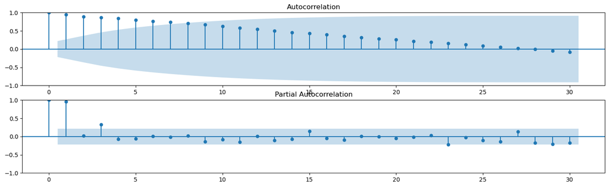

```python
fig, ax = plt.subplots(2,1,figsize=(18,5), sharex=False)
sm.graphics.tsa.plot_acf(train, lags=30, ax=ax[0])
sm.graphics.tsa.plot_pacf(train, lags=30, ax=ax[1])
plt.show();
```

### SARIMA

```python
# Fit the SARIMA model with Box-Cox transformation
pipeline = Pipeline([
    ("boxcox", BoxCoxEndogTransformer()),
    ("model", pm.AutoARIMA(seasonal=True, m=4, information_criterion='aic', test='kpss',
                           maxiter=150, suppress_warnings=True, trace=True, verbose=1))
])

# Fit the model to the training data
model = pipeline.fit(train)

# Display predictions
print("Pipeline predictions:", pipeline.predict(8))  # 5-step forecast from the pipeline
print("Model predictions:", model.predict(8))  # Direct prediction from the model inside the pipeline
```

```
Performing stepwise search to minimize aic
 ARIMA(2,1,2)(1,0,1)[4] intercept   : AIC=3133.776, Time=0.12 sec
 ARIMA(0,1,0)(0,0,0)[4] intercept   : AIC=3148.455, Time=0.00 sec
 ARIMA(1,1,0)(1,0,0)[4] intercept   : AIC=3148.878, Time=0.01 sec
 ARIMA(0,1,1)(0,0,1)[4] intercept   : AIC=3147.051, Time=0.02 sec
 ARIMA(0,1,0)(0,0,0)[4]             : AIC=3147.853, Time=0.00 sec
 ARIMA(2,1,2)(0,0,1)[4] intercept   : AIC=3132.253, Time=0.05 sec
 ARIMA(2,1,2)(0,0,0)[4] intercept   : AIC=3137.200, Time=0.04 sec
 ARIMA(2,1,2)(0,0,2)[4] intercept   : AIC=3133.439, Time=0.07 sec
 ARIMA(2,1,2)(1,0,0)[4] intercept   : AIC=3132.173, Time=0.21 sec
 ARIMA(2,1,2)(2,0,0)[4] intercept   : AIC=3134.088, Time=0.08 sec
 ARIMA(2,1,2)(2,0,1)[4] intercept   : AIC=3135.708, Time=0.13 sec
 ARIMA(1,1,2)(1,0,0)[4] intercept   : AIC=3136.736, Time=0.04 sec
 ARIMA(2,1,1)(1,0,0)[4] intercept   : AIC=3133.780, Time=0.03 sec
 ARIMA(3,1,2)(1,0,0)[4] intercept   : AIC=3137.878, Time=0.12 sec
 ARIMA(2,1,3)(1,0,0)[4] intercept   : AIC=3135.182, Time=0.14 sec
 ARIMA(1,1,1)(1,0,0)[4] intercept   : AIC=3147.754, Time=0.02 sec
 ARIMA(1,1,3)(1,0,0)[4] intercept   : AIC=3137.085, Time=0.05 sec
 ARIMA(3,1,1)(1,0,0)[4] intercept   : AIC=3135.774, Time=0.06 sec
 ARIMA(3,1,3)(1,0,0)[4] intercept   : AIC=3138.911, Time=0.08 sec
 ARIMA(2,1,2)(1,0,0)[4]             : AIC=3137.250, Time=0.07 sec

Best model:  ARIMA(2,1,2)(1,0,0)[4] intercept
Total fit time: 1.372 seconds
Pipeline predictions: [121.0496767  120.2245483  120.6407187  121.77902693 121.75575078
 121.17968973 121.38800446 122.13195681]
Model predictions: [121.0496767  120.2245483  120.6407187  121.77902693 121.75575078
 121.17968973 121.38800446 122.13195681]
```

```python
# Best model
model.set_params()
```

```
Pipeline(steps=[('boxcox', BoxCoxEndogTransformer()),
                ('model', AutoARIMA(m=4, maxiter=150, trace=True))])
```

```python
model_SARIMA = pm.ARIMA(order=(2,1,2), seasonal_order=(1,0,0,4), solver='lbfgs', maxiter=150,
                        enforce_invertibility=False, suppress_warnings=False, scoring='mse').fit(train)
model_SARIMA.summary()
```

SARIMAX Results

| Dep. Variable: | y | No. Observations: | 80 |
| --- | --- | --- | --- |
| Model: | SARIMAX(2, 1, 2)x(1, 0, [], 4) | Log Likelihood | -154.607 |
| Date: | Mon, 04 Nov 2024 | AIC | 323.214 |
| Time: | 02:18:11 | BIC | 339.800 |
| Sample: | 0 | HQIC | 329.859 |
|  | - 80 |  |  |
| Covariance Type: | opg |  |  |

|  | coef | std err | z | P>\|z\| | [0.025 | 0.975] |
| --- | --- | --- | --- | --- | --- | --- |
| intercept | 0.7160 | 0.281 | 2.544 | 0.011 | 0.164 | 1.268 |
| ar.L1 | 0.0717 | 0.146 | 0.490 | 0.624 | -0.215 | 0.358 |
| ar.L2 | -0.7502 | 0.130 | -5.768 | 0.000 | -1.005 | -0.495 |
| ma.L1 | -0.2856 | 0.202 | -1.412 | 0.158 | -0.682 | 0.111 |
| ma.L2 | 0.2803 | 0.227 | 1.232 | 0.218 | -0.165 | 0.726 |
| ar.S.L4 | -0.3031 | 0.136 | -2.235 | 0.025 | -0.569 | -0.037 |
| sigma2 | 2.9021 | 0.492 | 5.899 | 0.000 | 1.938 | 3.866 |

| Ljung-Box (L1) (Q): | 0.01 | Jarque-Bera (JB): | 27.79 |
| --- | --- | --- | --- |
| Prob(Q): | 0.93 | Prob(JB): | 0.00 |
| Heteroskedasticity (H): | 1.66 | Skew: | 1.03 |
| Prob(H) (two-sided): | 0.20 | Kurtosis: | 5.04 |

Warnings:  
[1] Covariance matrix calculated using the outer product of gradients (complex-step).

```python
# Make forecasts
pred_SARIMA = model_SARIMA.predict(validation.shape[0])  # predict 20 steps into the future
```

```python
pred_SARIMA[0:20]
```

```
80    121.040288
81    120.409203
82    121.097123
83    122.364347
84    122.356008
85    121.905705
86    122.341590
87    123.201036
88    123.525246
89    123.467844
90    123.796517
91    124.430528
92    124.766674
93    124.860121
94    125.156053
95    125.651196
96    126.017822
97    126.223440
98    126.515029
99    126.932783
dtype: float64
```

```python
# Confidence interval
pred_SARIMA_conf_int = model_SARIMA.predict(validation.shape[0], return_conf_int=True)[1]

pred_SARIMA_conf_int[:20]
```

```
array([[117.70137235, 124.3792039 ],
       [116.1622348 , 124.65617217],
       [116.73304122, 125.46120559],
       [117.77379944, 126.9548944 ],
       [117.47533204, 127.23668407],
       [116.75414444, 127.05726524],
       [117.05462161, 127.62855813],
       [117.78770002, 128.61437163],
       [117.81650694, 129.23398444],
       [117.48472782, 129.4509592 ],
       [117.65450092, 129.93853217],
       [118.13641702, 130.72463801],
       [118.27636222, 131.25698554],
       [118.16707924, 131.5531621 ],
       [118.30646856, 132.0056369 ],
       [118.65901811, 132.64337396],
       [118.85295475, 133.18268997],
       [118.88095031, 133.56592963],
       [119.02146976, 134.00858904],
       [119.29868676, 134.56687889]])
```

```python
lower_limits = [k[0] for k in pred_SARIMA_conf_int]
upper_limits = [k[1] for k in pred_SARIMA_conf_int]
```

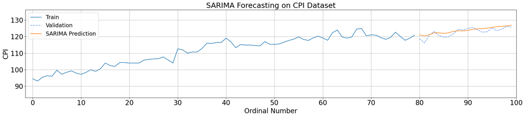

```python
# visualize the forecasts
plt.figure(figsize=(22,5))
plt.grid()

plt.plot(np.arange(0, train.shape[0]), train, label='Train', color='tab:blue')
plt.plot(np.arange(train.shape[0], train.shape[0] + validation.shape[0]), validation, '--', label='Validation', color='cornflowerblue')
plt.plot(np.arange(train.shape[0], train.shape[0] + validation.shape[0]), pred_SARIMA, label='SARIMA Prediction', color='tab:orange')

plt.axis([-1.5, len(y), min(y)-10, max(y)+10])
plt.xticks(range(0, len(y) + 10, 10), fontsize=20)
plt.yticks(fontsize=20)

plt.ylabel('CPI', fontsize=20)
plt.xlabel('Ordinal Number', fontsize=20)
plt.title('SARIMA Forecasting on CPI Dataset', fontsize=22)
plt.legend(loc='upper left', fontsize=16.5)
plt.tight_layout()
plt.show()
```

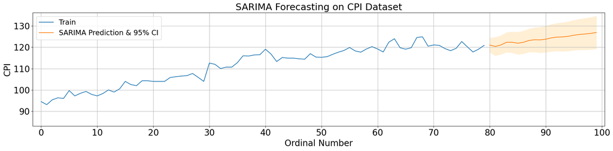

```python
# visualize the forecasts
plt.figure(figsize=(20,5))
plt.grid()

plt.plot(np.arange(0, train.shape[0]), train, label='Train', color='tab:blue')

# with confidence intervals
plt.plot(np.arange(train.shape[0], y.shape[0]), pred_SARIMA, label='SARIMA Prediction & 95% CI', color='tab:orange')
plt.fill_between(np.arange(train.shape[0], y.shape[0]), lower_limits, upper_limits, color='papayawhip')

plt.axis([-1.5, y.shape[0] + 0.5, min(y)-10, max(y)+10])
plt.xticks(range(0, y.shape[0] + 10, 10), fontsize=20)
plt.yticks(fontsize=20)
plt.ylabel('CPI', fontsize=20)
plt.xlabel('Ordinal Number', fontsize=20)
plt.title('SARIMA Forecasting on CPI Dataset', fontsize=22)
plt.legend(loc='upper left', fontsize=16.5)
plt.tight_layout()
plt.show()
```

```python
# MAPE function
def mape_(actual, pred):
    actual, pred = np.array(actual), np.array(pred)
    return np.mean(np.abs((actual - pred) / actual)) * 100

# RMSE
mse_SARIMA = mean_squared_error(validation, pred_SARIMA)
rmse_SARIMA = sqrt(mse_SARIMA)
print(f'RMSE: {rmse_SARIMA:.2f}')

# MAE
mae_SARIMA = mean_absolute_error(validation, pred_SARIMA)
print(f'MAE: {mae_SARIMA:.2f}')

# MAPE
mape_SARIMA = mape_(validation, pred_SARIMA)
print(f'MAPE: {mape_SARIMA:.2f}')
```

```
RMSE: 1.76
MAE: 1.48
MAPE: 1.22
```

#### Discussion on SARIMA

- Model Selection: Following a stepwise search that minimized the AIC, the SARIMA model with parameters (2,1,2)(1,0,0)[4] was chosen. Both annual and broad patterns are captured by this combination, which perfectly balances seasonal and non-seasonal components.
- Performance Metrics: Considering the seasonality of the CPI data, the model's RMSE of 1.76, MAE of 1.48, and MAPE of 1.22% show a reasonable fit with comparatively low prediction errors.
- Residual Analysis: The residuals indicate that the model was able to capture the majority of the pattern in the time series since they exhibit little autocorrelation. Kurtosis and mild skewness, however, suggest some departure from a perfect normal distribution.
- Prediction and Confidence Intervals: The 95% confidence intervals give appropriate constraints around the anticipated values, and the prediction closely resembles the observed validation pattern. This increases the forecast accuracy's resilience.

### Holt-Winters (Exponential Smoothing)

```python
model_HW = ExponentialSmoothing(train,
                                trend='add',
                                seasonal='mul',
                                seasonal_periods=4,
                                initialization_method="estimated",
                                use_boxcox=False).fit(optimized=True, remove_bias=False)

# predictions for the validation period
pred_HW = model_HW.predict(start=train.shape[0], end=train.shape[0] + validation.shape[0] - 1)
print(pred_HW.head())
```

```
80    120.585502
81    119.719396
82    120.723141
83    122.182506
84    121.892061
dtype: float64
```

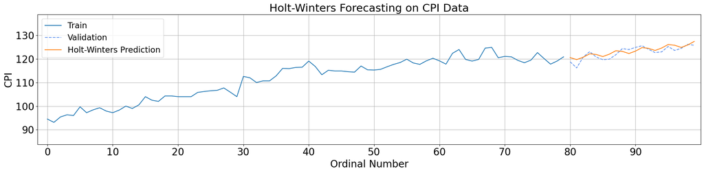

```python
plt.figure(figsize=(20,5))
plt.grid()

plt.plot(np.arange(0, train.shape[0]), train, label='Train', color='tab:blue')
plt.plot(np.arange(train.shape[0], train.shape[0] + validation.shape[0]), validation, '--', label='Validation', color='cornflowerblue')
plt.plot(np.arange(train.shape[0], train.shape[0] + validation.shape[0]), pred_HW, label='Holt-Winters Prediction', color='tab:orange')

plt.axis([-1.5, train.shape[0] + validation.shape[0], min(train.min(), validation.min()) * 0.9, max(train.max(), validation.max()) * 1.1])
plt.xticks(range(0, train.shape[0] + validation.shape[0], 10), fontsize=20)
plt.yticks(fontsize=20)

plt.ylabel('CPI', fontsize=20)
plt.xlabel('Ordinal Number', fontsize=20)
plt.title('Holt-Winters Forecasting on CPI Data', fontsize=22)
plt.legend(loc='upper left', fontsize=16.5)
plt.tight_layout()
plt.show();
```

```python
# RMSE
mse_HW = mean_squared_error(validation, pred_HW)
rmse_HW = sqrt(mse_HW)
print(f'RMSE: {rmse_HW:.2f}')

# MAE
mae_HW = mean_absolute_error(validation, pred_HW)
print(f'MAE: {mae_HW:.2f}')

# MAPE
mape_HW = mape_(validation, pred_HW)
print(f'MAPE: {mape_HW:.2f}')
```

```
RMSE: 1.52
MAE: 1.30
MAPE: 1.07
```

#### Discussion

Graph Analysis:

- The Holt-Winters Additive-Multiplicative-NoDamp model's forecast plot demonstrates how well it matches the real CPI values throughout the course of the time series. This alignment shows that the seasonal patterns and general trend in the CPI data are being effectively captured by the model. The graph's validation period also exhibits little departure from the real values, confirming the accuracy of this forecasting method.

# Model Performance/ Decision on Optimal Model

```python
data = {
    'Model': [
        'Seasonal RW', 'Additive', 'Multiplicative', 'Log additive',
        'ARIMA(2,1,1)', 'ARIMA(1,1,1)', 'ARIMA(0,1,3)', 'ARIMA(2,1,0)',
        'SARIMA(2,1,2)(1,0,0)[4]', 'Holt-Winters Model'
    ],
    'RMSE': [
        3.82, 2.59, 2.58, 2.75,
        1.5684, 1.8248, 1.5903, 1.5656,
        1.76, 1.52
    ]
}

df_models_rmse = pd.DataFrame(data)
df_models_rmse
```

|  | Model | RMSE |
| --- | --- | --- |
| 0 | Seasonal RW | 3.8200 |
| 1 | Additive | 2.5900 |
| 2 | Multiplicative | 2.5800 |
| 3 | Log additive | 2.7500 |
| 4 | ARIMA(2,1,1) | 1.5684 |
| 5 | ARIMA(1,1,1) | 1.8248 |
| 6 | ARIMA(0,1,3) | 1.5903 |
| 7 | ARIMA(2,1,0) | 1.5656 |
| 8 | SARIMA(2,1,2)(1,0,0)[4] | 1.7600 |
| 9 | Holt-Winters Model | 1.5200 |

- Lowest RMSE: The Holt-Winters model had the greatest prediction accuracy on the validation dataset, with the lowest Root Mean Square Error (RMSE) of 1.52 among the models assessed. This outcome shows that, in comparison to other models, it does a good job of minimizing forecast errors.
- Efficient Trend and Seasonality Management: The Holt-Winters model closely matches the structure of the real data and successfully captures the trend and seasonal components of the CPI data. It is appropriate for CPI forecasting because it can take seasonal fluctuations in a dynamic time series into account.
- Consistency Across Forecasts: The model consistently performed across the course of the time series, demonstrating dependable alignment with actual values over time, in addition to producing accurate forecasts. For reliable long-term forecasting, this stability is essential.

All things considered, the Holt-Winters model is the best option because of its excellent RMSE performance, adept management of trend and seasonality, and reliable prediction accuracy, which make it a good fit for the features of the CPI data.

# Forecast

Finally, we forecast the CPI values for the period from March 2022 to December 2023 using the optimal model.

```python
# train the model on the full dataset
full_model_HW = ExponentialSmoothing(y,
                                     trend='add',
                                     seasonal='mul',
                                     seasonal_periods=4,
                                     initialization_method="estimated",
                                     use_boxcox=False).fit(optimized=True, remove_bias=False)

# forecast 8 quarters ahead (Mar 2022 to Dec 2023)
forecast_steps = 8
forecast_HW = full_model_HW.predict(start=len(y), end=len(y) + forecast_steps - 1)
forecast_HW.index = pd.period_range(start='2022Q1', periods=forecast_steps, freq='Q')

print("Holt-Winters Forecast:")
forecast_HW
```

```
Holt-Winters Forecast:
```

```
2022Q1    125.946723
2022Q2    125.027000
2022Q3    126.184396
2022Q4    127.666318
2023Q1    127.207000
2023Q2    126.274952
2023Q3    127.440766
2023Q4    128.934287
Freq: Q-DEC, dtype: float64
```

```python
# create a dataFrame with the forecasted values
forecast_df = pd.DataFrame({
    'Quarter': forecast_HW.index.strftime('%b-%y'),
    'CPI': forecast_HW.values
})

forecast_df.to_csv('CPI_forecast.csv', index=False)
forecast_df
```

|  | Quarter | CPI |
| --- | --- | --- |
| 0 | Mar-22 | 125.946723 |
| 1 | Jun-22 | 125.027000 |
| 2 | Sep-22 | 126.184396 |
| 3 | Dec-22 | 127.666318 |
| 4 | Mar-23 | 127.207000 |
| 5 | Jun-23 | 126.274952 |
| 6 | Sep-23 | 127.440766 |
| 7 | Dec-23 | 128.934287 |

# Conclusion

The study concluded that the best forecasting technique for predicting quarterly CPI levels was the Holt-Winters Exponential Smoothing model. The model's capacity to faithfully capture past trends and seasonality in CPI data has been crucial in producing accurate and trustworthy projections. Businesses may anticipate cost increases and make strategic adjustments to retain profitability in a market that is susceptible to inflation due to the results, which have significant ramifications for them. In a similar vein, governments may use these projections to anticipate inflationary pressures and create preventative policies that protect economic stability. This model is an essential tool for making well-informed decisions by improving insight into upcoming CPI trends. This keeps stakeholders flexible and proactive in the face of changing economic situations. Businesses are better equipped to handle the difficulties presented by inflation because to this predictive aptitude, which also increases their ability to withstand changes in the economy in the years to come.

# Test Error

```python
import pandas as pd
from sklearn.metrics import mean_squared_error

CPI_test = pd.read_csv('CPI_test.csv')
CPI_test_values = CPI_test['CPI'].values

CPI_forecast = pd.read_csv('CPI_forecast.csv')
CPI_forecast_values = CPI_forecast['CPI'].values

test_error = mean_squared_error(CPI_test_values, CPI_forecast_values)
print(f'Test Error (MSE): {test_error:.4f}')
```

[output not shown]